# Geospatial Analysis with R

Class 5

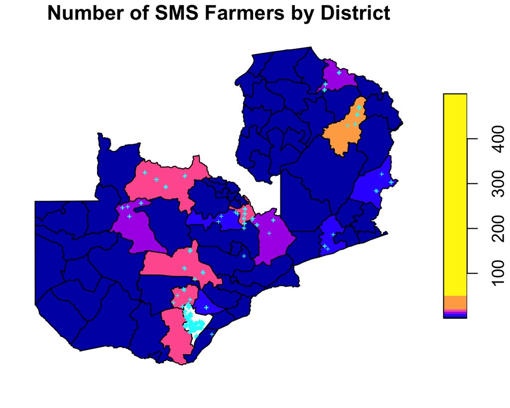

```r
library(sf)
library(dplyr)
f <- system.file("extdata", "farmer_spatial.csv", package = "geospaar")
farmers <- readr::read_csv(f)
farmers <- farmers %>% select(uuid, x, y) %>% distinct() %>%
  st_as_sf(., coords = c("x", "y"))
f <- system.file("extdata", "districts.shp", package = "geospaar")
dists <- read_sf(f)
st_crs(farmers) <- st_crs(dists)

# join farmers with districts (h/t https://mattherman.info/blog/point-in-poly/)
farmers_in_dists <- st_join(farmers, dists, join = st_within) %>%
  tidyr::drop_na()
farmer_count <- count(as_tibble(farmers_in_dists), distName)
dists_w_farmers <- left_join(dists, farmer_count) %>%
  mutate(n = ifelse(is.na(n), 0, n))

png("figures/sms-farmers.png", height = 4, width = 5, res = 300,
    units = "in")
plot(dists_w_farmers["n"], breaks = c(0, 5, 10, 15, 20, 50, 500),
     reset = FALSE, main = "Number of SMS Farmers by District")
plot(farmers %>% filter(uuid %in% unique(farmers_in_dists$uuid)) %>%
       st_geometry(), add = TRUE, pch = "+", col = "cyan", cex = 0.5)
dev.off()
```

## Today

- Projects and package set-up
- `git` / GitHub
  - syncing, commit, push, pull, branching, merging
- data folder and lazy loads
- inst folder and how to get at it
- If time
  - RMarkdown
  - The `R` ecosystem
  - Building blocks of R: data types, functions, etc

## Git exercises (1)

- Open your personal R repo (e.g. `mjc346` in RStudio)
- Create a new branch, `test_merge`. You can create this branch in the Git tab, or in Terminal, using `git checkout -b test_merge`
- With the new branch active, create a new file `test_function` within the R folder. Create a simple function that takes a number `x` as an input, and prints “`x` is my favorite number!”. Save and commit this file in the new branch.
- Switch back to the `main` branch. You should see a pop-up message. What happens to the `test_function.R` file? Can you see it in your file explorer?
- merge the new file to the main branch using the command `git merge test_merge` in Terminal. What happens?
- The `merge` command automatically merges and commits changes to the main branch

## Git exercises (2)

- In the `test_merge` branch, open the Description file. Update the version to 0.0.2. Save and commit.
- Switch to the `main` branch. Add a second author in the Author line. Save and commit.
- Now test merging the change from `test_merge` to `main` using `git merge test_merge`. Does this work?

## Tips and Tricks

- Tab completion and shortcuts
- Reusing code
- Code syntax
- [Posting guide](https://www.r-project.org/posting-guide.html)

## Knowing how to get help as a skillset

- Slack posting guide
- Getting help via the search engine
- (Eventually) posting to listserves

## Search Engine Science

- Sometimes you just need the error message

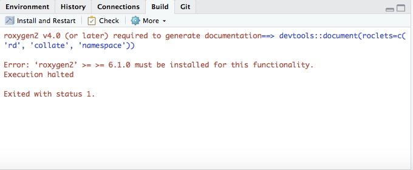

## Search Engine Science

- Sometimes you need to search

  ```
  fatal: unable to access 'https://github.com/agroimpacts/xyz346.git/':
  error setting certificate verify locations:
   CAfile: C:/Users/xyz/Desktop/ADP/RStudio/xyz346/Git/mingw64/ssl/
   certs/ca-bundle.crt
   CApath: none
  ```

- How you search matters

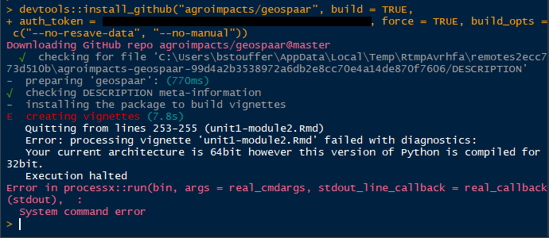

## Listserves

[figure not shown]

## Package functions

- `install.packages` : installs binary packages from CRAN
- `devtools::install_github`: installs from Github
- `devtools::install("C:/Users/micha/Documents/geospaar/")` to install locally

## Data in packages

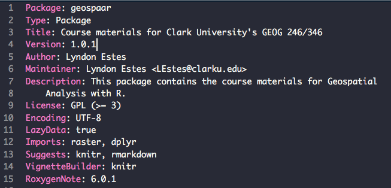

- packages often include example data
- Lazy loading data only loads when used
- Lazy loaded data in data/ folder
  - formats: .R, .rda, .RData, .tab, .txt, .csv
- Non lazy loads (raw data) in inst/extdata

```r
ls()
```

```
character(0)
```

```r
data("farmers_env", package = "geospaar")
ls()
```

```
[1] "farmers_env"
```

```r
farmers_env
```

```
        uuid        geometry     rain district
1   009a8424 27.256, -16.926 66.93754       11
2   00df166f 26.942, -16.504 72.00297       11
3   02671a00 27.254, -16.914 66.93754       11
4   03f4dcca 27.237, -16.733 69.78009       11
5   042cf7b3 27.138, -16.807 75.14184       11
6   05618404 26.875, -16.611 66.09323       11
7   064beba0 26.752, -16.862 58.36053       20
8   083a46a2 26.977, -16.765 70.38586       11
9   08eb2224 26.912, -16.248 53.95671       59
10  0ab761d6 27.113, -16.950 72.43802       11
11  0bd19b6a 26.772, -16.860 58.36053       20
12  0c0c6ed8 26.794, -16.843 57.79966       11
13  0c18f625 26.862, -16.674 68.36250       11
14  0cbc4225 26.859, -16.176 57.92710       59
```

[output cut: 779 more lines]

```r
rm(list = ls())
ls()
```

```
character(0)
```

```r
library(geospaar)
ls()
```

```
character(0)
```

```r
farmers_env
```

```
Simple feature collection with 793 features and 3 fields
Geometry type: POINT
Dimension:     XY
Bounding box:  xmin: 24.777 ymin: -18.222 xmax: 33.332 ymax: -8.997
CRS:           NA
# A tibble: 793 × 4
   uuid             geometry  rain district
 * <chr>             <POINT> <dbl>    <dbl>
 1 009a8424 (27.256 -16.926)  66.9       11
 2 00df166f (26.942 -16.504)  72.0       11
 3 02671a00 (27.254 -16.914)  66.9       11
 4 03f4dcca (27.237 -16.733)  69.8       11
 5 042cf7b3 (27.138 -16.807)  75.1       11
 6 05618404 (26.875 -16.611)  66.1       11
 7 064beba0 (26.752 -16.862)  58.4       20
 8 083a46a2 (26.977 -16.765)  70.4       11
 9 08eb2224 (26.912 -16.248)  54.0       59
10 0ab761d6  (27.113 -16.95)  72.4       11
# ℹ 783 more rows
```

```r
ls()
```

```
character(0)
```

## Raw data in inst/extdata

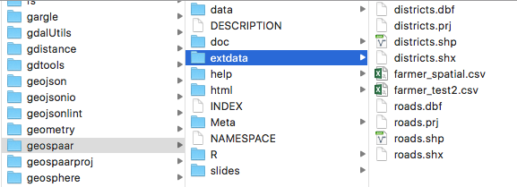

```r
system.file("extdata", package = "geospaar")
```

```
[1] "/Library/Frameworks/R.framework/Versions/4.4-arm64/Resources/library/geospaar/extdata"
```

```r
dir(system.file("extdata", package = "geospaar"))
```

```
 [1] "cdf_corn.csv"          "chilanga_farmer"       "chirps.tif"
 [4] "districts.geojson"     "EJ_POLY.cpg"           "EJ_POLY.dbf"
 [7] "EJ_POLY.prj"           "EJ_POLY.sbn"           "EJ_POLY.sbx"
[10] "EJ_POLY.shp"           "EJ_POLY.shp.xml"       "EJ_POLY.shx"
[13] "FAOSTAT_maize.csv"     "FAOSTAT_sorghum.csv"   "FAOSTAT_wheat.csv"
[16] "farmer_spatial.csv"    "filt_data.rda"         "roads.geojson"
[19] "train_reference.csv"   "westluse.rdc"          "westluse.rst"
[22] "westroad.vct"          "westroad.vdc"          "whittier_down_d_h.rda"
[25] "whittier_mid_d_h.rda"  "whittier_up_d_h.rda"
```

```r
f <- system.file("extdata", "farmer_spatial.csv", package = "geospaar")
head(read.csv(f))
```

```
      uuid      x       y       date season rained planted
1 009a8424 27.256 -16.926 2015-11-15      1      0       0
2 00df166f 26.942 -16.504 2015-11-15      1      0       0
3 02671a00 27.254 -16.914 2015-11-15      1      0       0
4 03f4dcca 27.237 -16.733 2015-11-15      1      0       0
5 042cf7b3 27.138 -16.807 2015-11-15      1      0       0
6 05618404 26.875 -16.611 2015-11-15      1      0       0
```

## Other package folders

- See [Chap 9 of “R Packages”](https://r-pkgs.org/misc.html) for more examples of R packages folders.

## A look at RMarkdown

Chunk options

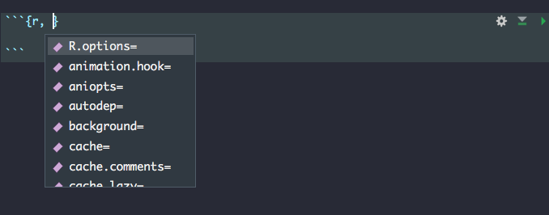

Rmarkdown demo by Lei Song [RMarkdown gallery](https://rmarkdown.rstudio.com/lesson-1.html)

## RMarkdown exercises

- In your personal R project, Create new RMarkdown file using `usethis::use_vignette(name = "example_vignette")`
- Create chunks for the following:
  - Load the `geospaar` package
  - Load the `chirps` data and print its structure using `str(chirps)`
  - Plot `chirps` data using `raster::plot(chirps)`. Above this chunk, include a text description for the CHIRPS data using different text formatting (bold, italics, etc). You can see information on the `CHIRPS` data in the `man` folder.
  - Include a chunk with an obvious error, like `5 + "string"`
  - Try knitting this RMD using different [chunk options](https://rmarkdown.rstudio.com/lesson-3.html)

## The R Ecosystem

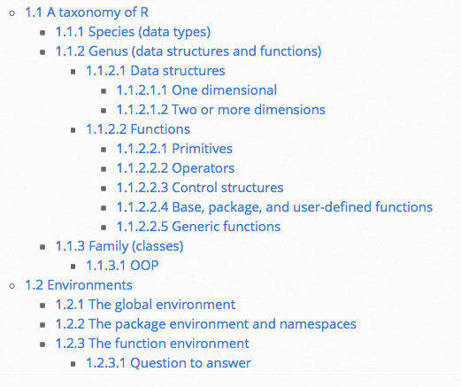

## The R Ecosystem

### Common objects

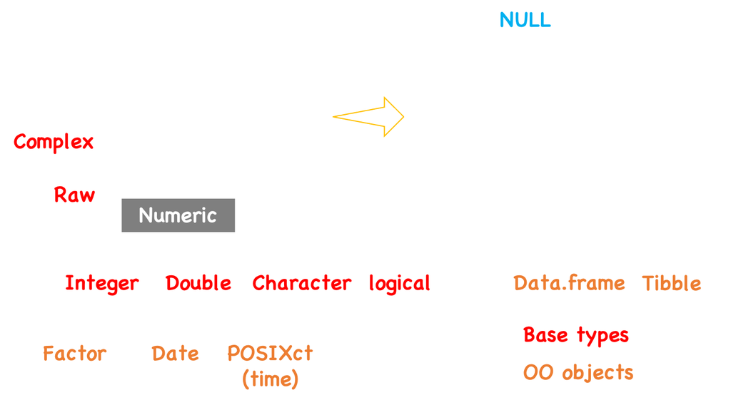

Credit: L. Song

## The R Ecosystem

### Data types

There are 6 atomic data types:

- character e.g. `'hello world'`, `'abc'`
- double (real or decimal) e.g. `10`, `3.14`, `1e10`
- integer e.g. `1L`
- logical e.g. `TRUE`, `FALSE`, `T`, `F`
- complex e.g. `1 + 3i` (not commonly used by us)
- *raw* (rarely used by us)

## The R Ecosystem

### Special data types

- `NULL`: Does not exist
- Missing data: `NA`. A special logical type that converts into the type it is associated with.
- Infinity: `Inf` (e.g. `1 / 0`) and `-Inf` (e.g. `-1 / 0`. A special double type.
- Undefined value: `NaN`. Also a special double type. (e.g. `0 / 0`)

## The R Ecosystem

### Special data types

- Date: `as.Date('1970-1-5')`
- Time: `as.POSIXct('1970-1-5')`
- Factor: factors are integers with associated labels.

## The R Ecosystem

### Checking data type

- `typeof(x)`
- `is.xxx(x)`:
  - e.g. `is.double(x)`, `is.integer(x)`, `is.logical(x)`, `is.character(x)`, `is.complex(x)`, `is.raw(x)`, `is.factor`
  - `is.numeric(x)`
  - e.g. `is.na(y)`, `is.nan(y)`, `is.null(y)`, `is.infinite(y)`, `is.finite(y)`.

## The R Ecosystem

### Converting data type

- `as.xxx(x)`:
  - e.g. `as.numeric(x)`, `as.double(x)`, `as.character(x)`, `as.integer(x)`, `as.logical(x)`, `as.complex(x)`, `as.raw(x)`, `as.factor(x)`, `as.Date(x)`, `as.POSIXct(x)`.
- logical < integer < double < character

## The R Ecosystem

### Data structures

- Atomic vectors (most commonly thought of kind):
  - A sequence of objects of the **same class**.
  - Arrays and matrices are vectors with more than one dimension.
    - Matrices have 2 dimensions.
    - Arrays could have higher dimensions.
- Lists
  - Lists can contain objects of **different classes**.
  - Lists can be converted list-matrix or list-array by defining dimensions.
  - `data.frame` and `tibble` are S3 objects that are lists in tabular form

## The R Ecosystem

### Vectors

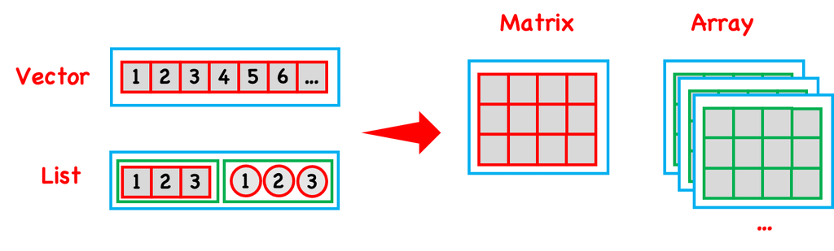

Credit: L. Song

## Let’s create some data

- `vector`
- `matrix`
- `data.frame`
- `list`

## Creating a vector

```r
v1 <- c(1,2,3,4,5)
v2 <- 6:10
print(v1)
```

```
[1] 1 2 3 4 5
```

```r
print(v2)
```

```
[1]  6  7  8  9 10
```

## Combining vectors

```r
v1 <- c(1,2,3,4,5)
v2 <- 6:10
v3 <- c(v1, v2)
print(v3)
```

```
 [1]  1  2  3  4  5  6  7  8  9 10
```

```r
print(class(v3))
```

```
[1] "numeric"
```

## Combining vectors

What happens when you combine data types in a vector?

```r
v4 <- c(v1, "test")
print(v4)
```

```
[1] "1"    "2"    "3"    "4"    "5"    "test"
```

```r
print(class(v4))
```

```
[1] "character"
```

## Vectorized operations

```r
v1 <- 1:9
print(v1)
```

```
[1] 1 2 3 4 5 6 7 8 9
```

```r
print(v1 + 5) ## addition applied to each element in vector
```

```
[1]  6  7  8  9 10 11 12 13 14
```

```r
print(v1 * 3) ## multiplication applied to each element in vector
```

```
[1]  3  6  9 12 15 18 21 24 27
```

## Accessing elements in vector

```r
v1 <- (1:9)*3
print(v1)
```

```
[1]  3  6  9 12 15 18 21 24 27
```

```r
print(v1[4])
```

```
[1] 12
```

```r
v1 <- letters[1:7]
print(paste0("This letter is ", v1)) # paste0 concatenates strings
```

```
[1] "This letter is a" "This letter is b" "This letter is c" "This letter is d"
[5] "This letter is e" "This letter is f" "This letter is g"
```

Question: How would you say “Letter 1 is a”, “Letter 2 is b”, etc.

## Creating a matrix

```r
v1 <- 1:9
m1 <- matrix(v1, nrow = 3, byrow = T)
m2 <- cbind(v1 = 1:3, v2 = 1:3, v3 = 0:0)
print(m1)
```

```
     [,1] [,2] [,3]
[1,]    1    2    3
[2,]    4    5    6
[3,]    7    8    9
```

```r
print(m2)
```

```
     v1 v2 v3
[1,]  1  1  0
[2,]  2  2  0
[3,]  3  3  0
```

## Accessing elements in a matrix

```r
m2 <- cbind(v1 = 1:3, v2 = 1:3, v3 = 0:0)
print(m2)
```

```
     v1 v2 v3
[1,]  1  1  0
[2,]  2  2  0
[3,]  3  3  0
```

```r
print("first row:")
```

```
[1] "first row:"
```

```r
print(m2[1, ])
```

```
v1 v2 v3
 1  1  0
```

```r
print("second column")
```

```
[1] "second column"
```

```r
print(m2[, 2])
```

```
[1] 1 2 3
```

```r
print("access by column name")
```

```
[1] "access by column name"
```

```r
print(m2[, "v2"])
```

```
[1] 1 2 3
```

Question: Create a 3 row, 4 column matrix, where the first column is (1, 2, 3), second column is (4, 5, 6 ) etc.

## Lists

Lists can mix object of different types.

```r
l <- list("a", 1, 0.5, TRUE)
print(l)
```

```
[[1]]
[1] "a"

[[2]]
[1] 1

[[3]]
[1] 0.5

[[4]]
[1] TRUE
```

```r
print(str(l)) # structure of l
```

```
List of 4
 $ : chr "a"
 $ : num 1
 $ : num 0.5
 $ : logi TRUE
NULL
```

## Lists

Lists can also be nested.

```r
l1 <- list("a", 1, 0.5, TRUE)
l2 <- list(l1, "test", matrix(1:9, nrow = 3)) ## first element of l2 is a list.
print(l2)
```

```
[[1]]
[[1]][[1]]
[1] "a"

[[1]][[2]]
[1] 1

[[1]][[3]]
[1] 0.5

[[1]][[4]]
[1] TRUE


[[2]]
[1] "test"

[[3]]
     [,1] [,2] [,3]
[1,]    1    4    7
[2,]    2    5    8
[3,]    3    6    9
```

Question: what is the length of l1? what is the length of each element of l1? (use `length` function)

## Accessing elements in lists

Use double brackets `[[ ]]` to access elements in lists.

```r
l1 <- list("a", 1, 0.5, TRUE)
l2 <- list(l1, "test", matrix(1:9, nrow = 3)) ## first element of l2 is a list.
print(l2[[1]])
```

```
[[1]]
[1] "a"

[[2]]
[1] 1

[[3]]
[1] 0.5

[[4]]
[1] TRUE
```

```r
print(l2[[2]])
```

```
[1] "test"
```

```r
print(l2[[3]])
```

```
     [,1] [,2] [,3]
[1,]    1    4    7
[2,]    2    5    8
[3,]    3    6    9
```

Question: The first element of `l2` is a list. Access this first element from `l2`, then the 4th element from `l1`

## Data frames

We will use data frames A LOT. Data frames are really tables, but they are stored in R as lists, with the following conditions.

- Each element in the list represents a column.
- Each element in the list is an atomic vector.
- The length of each vector is the same (the number of rows)

```r
m1 <- cbind(1:3, letters[1:3])
print(m1) # a matrix cannot hold multiple data types.
```

```
     [,1] [,2]
[1,] "1"  "a"
[2,] "2"  "b"
[3,] "3"  "c"
```

```r
print(class(m1))
```

```
[1] "matrix" "array"
```

```r
df <- data.frame(numbers = 1:3, abc = letters[1:3])
print(df) # a data frame CAN hold multiple data types.
```

```
  numbers abc
1       1   a
2       2   b
3       3   c
```

```r
print(class(df))
```

```
[1] "data.frame"
```

## Useful functions

- `print`
- You can print just about anything, but as a generic function, `print` works differently for different types of objects.

```r
a <- "test"
df <- data.frame(numbers = 1:3, abc = letters[1:3])
print(a) # a data frame CAN hold multiple data types.
```

```
[1] "test"
```

```r
print(df)
```

```
  numbers abc
1       1   a
2       2   b
3       3   c
```

```r
methods(print) ## all the different ways to print...
```

```
  [1] print.acf*
  [2] print.activeConcordance*
  [3] print.AES*
  [4] print.all_vars*
  [5] print.anova*
  [6] print.any_vars*
  [7] print.aov*
  [8] print.aovlist*
  [9] print.ar*
 [10] print.Arima*
 [11] print.arima0*
 [12] print.AsIs
 [13] print.aspell*
 [14] print.aspell_inspect_context*
 [15] print.bbox*
```

[output cut: 323 more lines]

## Examining objects

- `ls`, `class`, `str`

```r
a <- "test"
df <- data.frame(numbers = 1:3, abc = letters[1:3])
ls() ## list objects in global environemtn
```

```
 [1] "a"  "df" "f"  "l"  "l1" "l2" "m1" "m2" "v1" "v2" "v3" "v4"
```

```r
class(df) ## class
```

```
[1] "data.frame"
```

```r
str(df) ## structure
```

```
'data.frame':   3 obs. of  2 variables:
 $ numbers: int  1 2 3
 $ abc    : chr  "a" "b" "c"
```

## Sampling

- Sample without replacement

```r
set.seed(1234) ## set a random seed
v <- 1:100
s <- sample(v, 50)
print(s)
```

```
 [1] 28 80 22  9  5 38 16  4 86 90 70 79 78 14 56 62 93 84 21 40 92 67 96 66 47
[26] 81 48  3 41 32 42 43  2 54 49 99 51  6 77 29 71 85 57  8 26 17 58 91 60 76
```

```r
print(sort(s))
```

```
 [1]  2  3  4  5  6  8  9 14 16 17 21 22 26 28 29 32 38 40 41 42 43 47 48 49 51
[26] 54 56 57 58 60 62 66 67 70 71 76 77 78 79 80 81 84 85 86 90 91 92 93 96 99
```

- Sample with replacement

```r
s2 <- sample(v, 50, replace = T)
print(sort(s2))
```

```
 [1]  2  3  3  6  6  9 10 17 17 19 20 22 22 25 27 28 30 32 35 36 41 41 48 50 51
[26] 55 57 58 58 60 61 63 63 65 66 70 70 71 72 76 77 80 83 85 85 86 86 87 90 96
```

## Does S2 have duplicates?

```r
s2_unique <- unique(s2)
print(length(s2))
```

```
[1] 50
```

```r
print(length(s2_unique))
```

```
[1] 40
```

```r
print(length(s2) == length(s2_unique))
```

```
[1] FALSE
```